# HW6

2025-03-29

# a.) Apply K-means, and hierarchical clustering to segment credit card customers using only quantitative variables.

# b.) Apply the elbow method to select an appropriate number of groups.

## K-mean and elbow

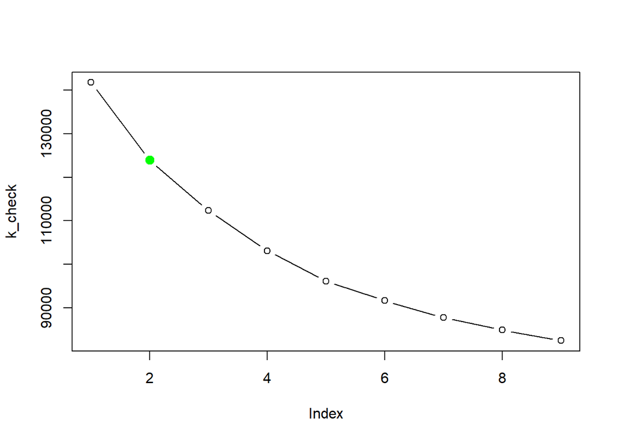

```r
k_check <- 1:9
for (i in 1:length(k_check)){
  k_mean <- kmeans(bank,i,nstart = 20)
  k_check[i] <- k_mean$tot.withinss
}
plot(k_check, type = "b")
points(2,k_check[2],col = "green", pch = 20, cex = 2)
```

## Hierarchical Clustering

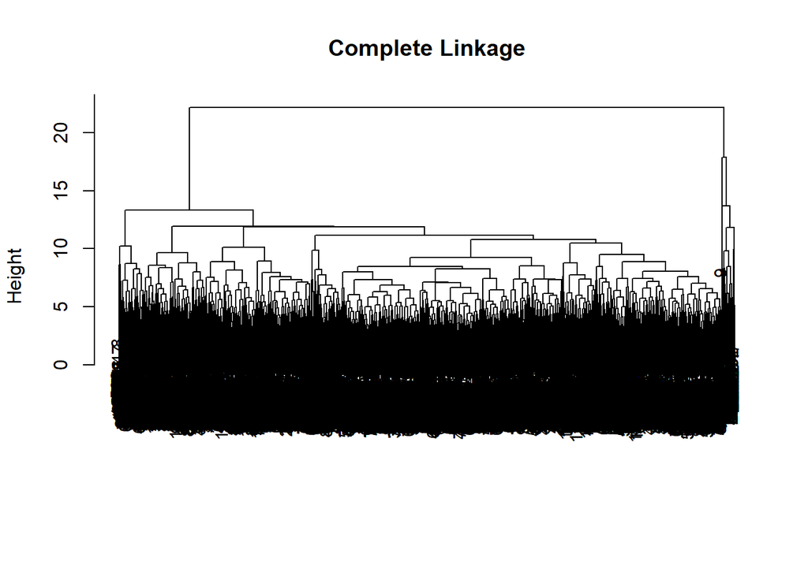

```r
bank_complete =hclust(dist(bank), method="complete")
bank_average =hclust(dist(bank), method="average")
bank_single =hclust(dist(bank), method="single")

plot(bank_complete ,main="Complete Linkage", xlab="", sub="", cex=.9)
```

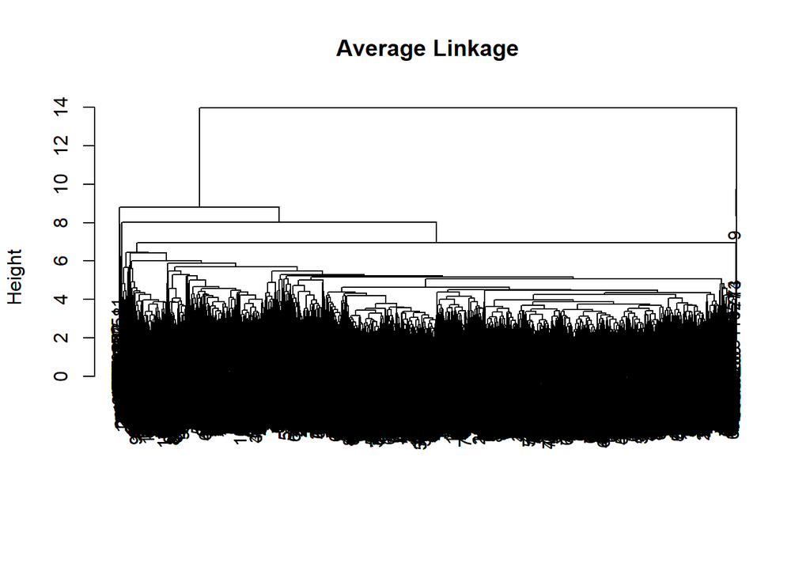

```r
plot(bank_average ,main="Average Linkage", xlab="", sub="", cex=.9)
```

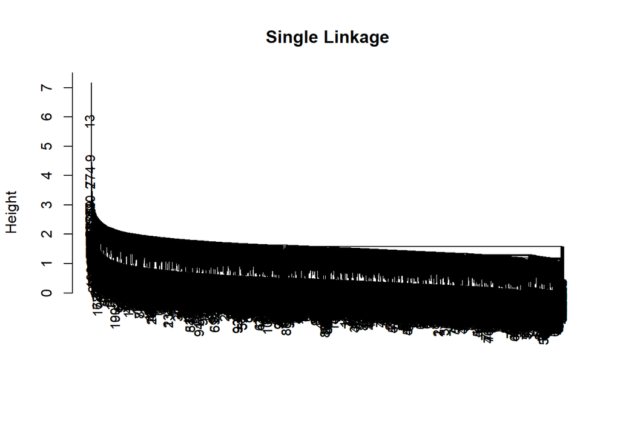

```r
plot(bank_single ,main="Single Linkage", xlab="", sub="", cex=.9)
```

# c.)Apply cluster validity indices to select an appropriate number of groups.

## cluster validity indices

```r
library(UniversalCVI)
k_clus_valid <- Hvalid(bank, kmax = 10, kmin = 2, indexlist = c("NCI", "DI", "DB", "DBs", "CSL", "CH"), method = "kmeans", p = 2, q = 2, corr = "pearson", nstart = 20, NCstart = TRUE)
```

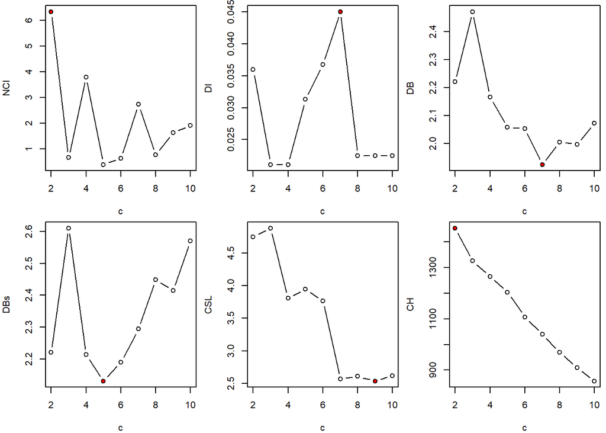

```r
plot_idx(k_clus_valid)
```

### cluster validate result compare with elbow: ได้ว่า กลุ่มที่สมควรแบ่งคือ 2 หรือ 7

## PCA 80% selection

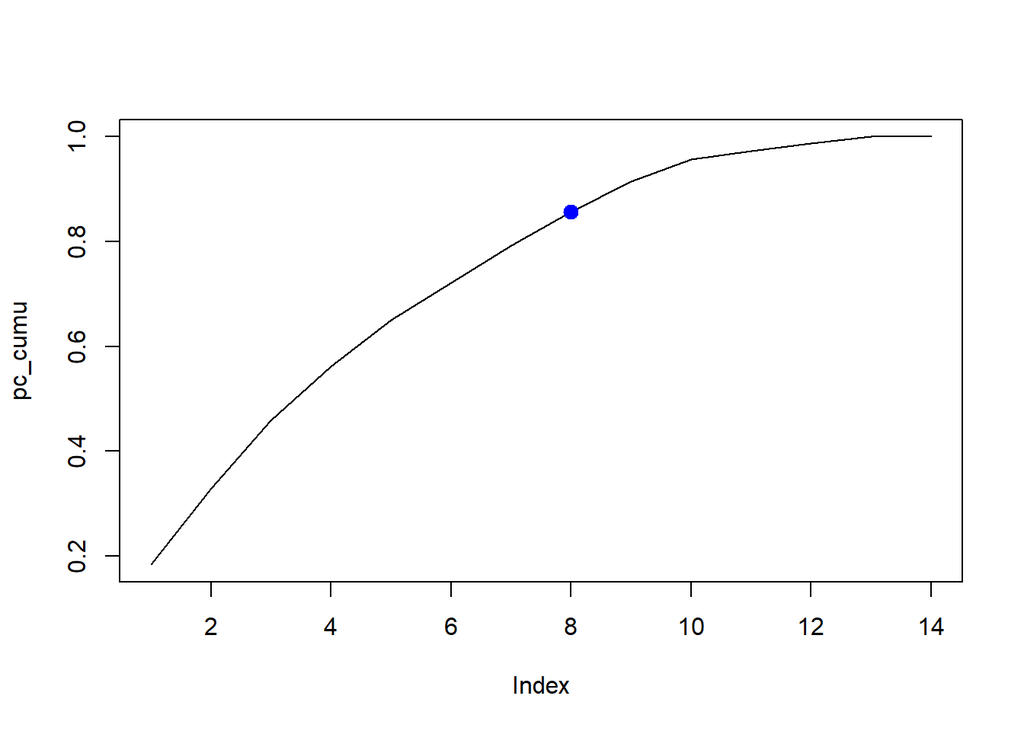

```r
pca <- prcomp(bank, scale = TRUE)
pc_var <- (pca$sdev)^2
pc_var_ratio <- pc_var/sum(pc_var)
pc_cumu <- cumsum(pc_var_ratio)
plot(pc_cumu, type = "l")
pc_select <- which(pc_cumu > 0.8)[1]
points(pc_select, pc_cumu[pc_select], col = "blue", pch = 20, cex = 2)
```

## hclust elbow

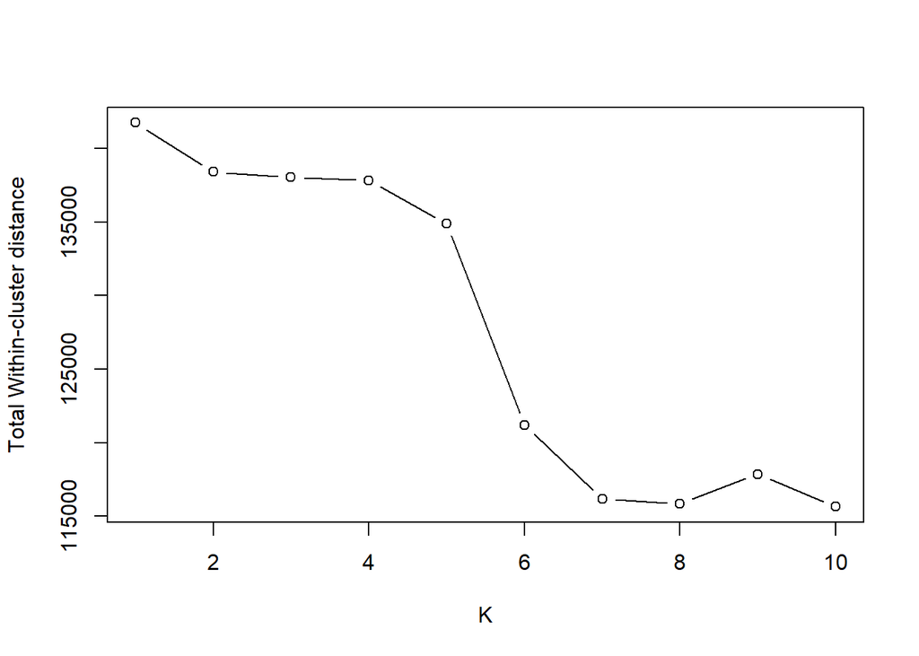

```r
k_com=rep(0,10)
k_avg=rep(0,10)
k_sin=rep(0,10)

for (k in 1:10)
{
  for (i in 1:k)
  {
    k_com[k]=k_com[k]+sum(dist(bank[cutree(bank_complete, k)==i,])^2)/sum(cutree(bank_complete, k)==i)
    k_avg[k]=k_avg[k]+sum(dist(bank[cutree(bank_average, k)==i,])^2)/sum(cutree(bank_average, k)==i)
    k_sin[k]=k_sin[k]+sum(dist(bank[cutree(bank_single, k)==i,])^2)/sum(cutree(bank_single, k)==i)

  }
}

plot(1:10,k_com,type="b",xlab="K",ylab = "Total Within-cluster distance")
```

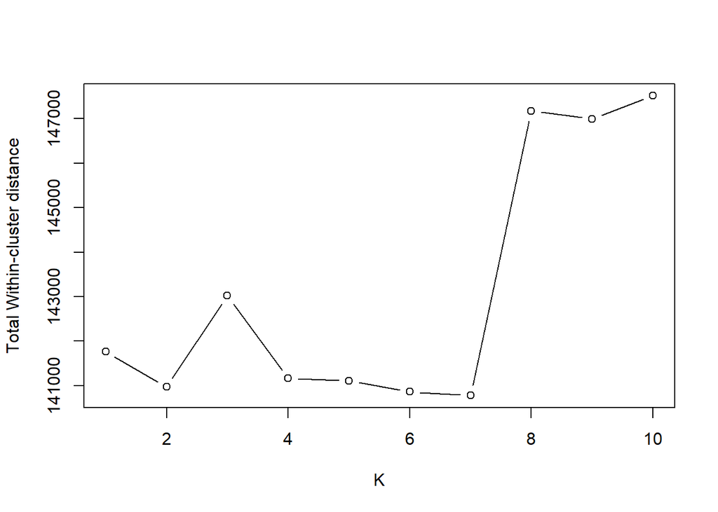

```r
plot(1:10,k_avg,type="b",xlab="K",ylab = "Total Within-cluster distance")
```

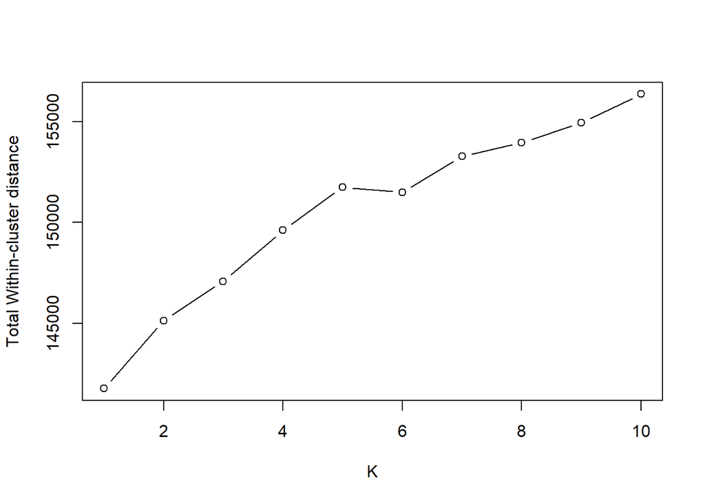

```r
plot(1:10,k_sin,type="b",xlab="K",ylab = "Total Within-cluster distance")
```

# d.)Select the final number of groups based on either a) or b) and explain your reasoning.

## k = 2

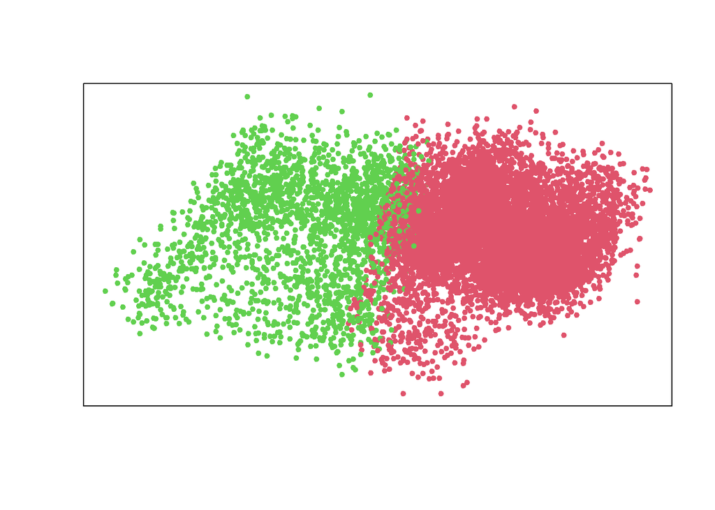

```r
k_elbow <- kmeans(bank, 2, nstart = 20)

plot(pca$x[,1:pc_select], col = k_elbow$cluster+1, pch=20, cex=1,ann = FALSE,xaxt='n',yaxt='n')
```

```r
k_elbow$centers
```

```
##   Customer_Age Dependent_count Months_on_book Total_Relationship_Count
## 1  0.006487411     -0.03253643    0.002731912               0.07172994
## 2 -0.023226750      0.11648953   -0.009781010              -0.25681331
##   Months_Inactive_12_mon Contacts_Count_12_mon Credit_Limit Total_Revolving_Bal
## 1            0.009789972           0.003620802   -0.4431926          0.00902417
## 2           -0.035050846          -0.012963486    1.5867539         -0.03230906
##   Avg_Open_To_Buy Total_Amt_Chng_Q4_Q1 Total_Trans_Amt Total_Trans_Ct
## 1      -0.4439086          -0.01152302      -0.1725559     -0.1101639
## 2       1.5893173           0.04125564       0.6177986      0.3944176
##   Total_Ct_Chng_Q4_Q1 Avg_Utilization_Ratio
## 1        -0.004244905             0.2211160
## 2         0.015197949            -0.7916571
```

```r
k2_cust_1 <- BankChurners[k_elbow$cluster == 1,]
k2_cust_2 <- BankChurners[k_elbow$cluster == 2,]
```

### จากการพิจารณา kmean = 2groups ได้ว่า

### กลุ่มที่ 1 = กลุ่มคนที่มีกำลังซื้อต่ำ credit limit ต่ำ ยอดค้างชำระสูง

### กลุ่มที่ 2 = กลุ่มคนที่มีกำลังซื้อมาก credit limit มาก ยอดค้างชำระต่ำค้างชำระต่ำ

### ซึ่ง Make Sense อยู่แล้ว จึงทำให้การแบ่ง 2 กลุ่มสามารถจำแนกลูกค้าและสามารถ

### หามาตรการในการ holding ลูกค้าไว้ได้ในระดับนึง

### อย่างเช่น กลุ่มลูกค้าที่มีกำลังจ่ายมาก credit limit มาก อาจมีการให้ โปรโมชั่นพิเศษสำหรับลูกค้า ที่แม้จะเป็นโปรโมชั่นที่ธนาคารแลดูเสียผลประโยชน์ แต่การทำให้ลูกค้าที่มี กำลังซื้อมากพึงพอใจ จะทำให้ธนาคารได้ผลประโยชน์ที่มาขึ้นในอนาคต

## k = 7

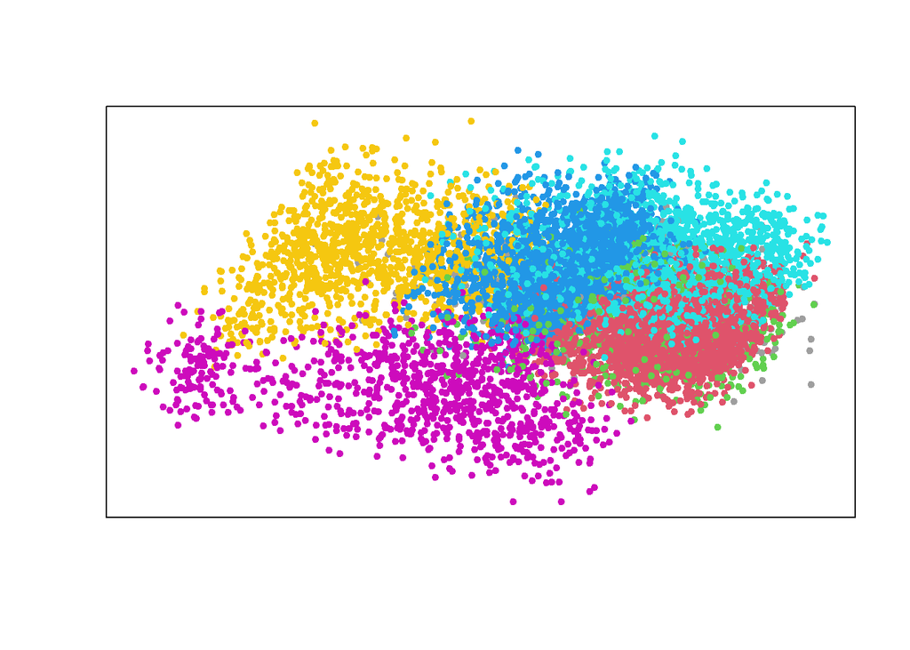

```r
k_7 <- kmeans(bank, 7, nstart = 20)

plot(pca$x[,1:pc_select], col = k_7$cluster+1, pch=20, cex=1,ann = FALSE,xaxt='n',yaxt='n')
```

```r
k_7$centers
```

```
##   Customer_Age Dependent_count Months_on_book Total_Relationship_Count
## 1 -0.035657563     0.514277203    -0.02838004              -0.04791856
## 2 -1.358860433    -0.582485120    -1.29143673               0.37151125
## 3  0.002982375     0.313721634     0.02345778              -0.03480077
## 4  1.286437181    -0.922058141     1.17038236               0.30875288
## 5 -0.127128588    -0.025436542    -0.10401970              -1.03633142
## 6  0.014550557     0.215354506     0.01702896               0.04673072
## 7  0.025132926    -0.000108681     0.02360707               0.35088281
##   Months_Inactive_12_mon Contacts_Count_12_mon Credit_Limit Total_Revolving_Bal
## 1             0.01622108           -0.26659715 -0.558081287          0.64200870
## 2            -0.18781669            0.25549441 -0.348618490          0.14518753
## 3             0.16792805            0.11670659 -0.311806391         -1.11813006
## 4             0.03371895            0.12666705 -0.345503318          0.27512461
## 5            -0.12014572           -0.25229644  0.555431845          0.28677865
## 6            -0.02136958            0.08256745  2.082558154          0.02185033
```

[output cut: 17 more lines]

### จากการพิจารณา kmean = 7 กลุ่ม สามารถจำแนกกลุ่มที่มีกำลังซื้อมาก credit limit มาก เช่นเดียวกับ kmean = 2 กลุ่ม ทั้งยังมีกลุ่มจำแนกอื่นๆที่น่าสนใจ

## จึงจะเลือก Final group เป็น K_mean = 7 กลุ่ม

```r
k_7$centers
```

```
##   Customer_Age Dependent_count Months_on_book Total_Relationship_Count
## 1 -0.035657563     0.514277203    -0.02838004              -0.04791856
## 2 -1.358860433    -0.582485120    -1.29143673               0.37151125
## 3  0.002982375     0.313721634     0.02345778              -0.03480077
## 4  1.286437181    -0.922058141     1.17038236               0.30875288
## 5 -0.127128588    -0.025436542    -0.10401970              -1.03633142
## 6  0.014550557     0.215354506     0.01702896               0.04673072
## 7  0.025132926    -0.000108681     0.02360707               0.35088281
##   Months_Inactive_12_mon Contacts_Count_12_mon Credit_Limit Total_Revolving_Bal
## 1             0.01622108           -0.26659715 -0.558081287          0.64200870
## 2            -0.18781669            0.25549441 -0.348618490          0.14518753
## 3             0.16792805            0.11670659 -0.311806391         -1.11813006
## 4             0.03371895            0.12666705 -0.345503318          0.27512461
## 5            -0.12014572           -0.25229644  0.555431845          0.28677865
## 6            -0.02136958            0.08256745  2.082558154          0.02185033
```

[output cut: 17 more lines]

```r
k7_clus_1 <- BankChurners[k_7$cluster == 1,]
k7_clus_2 <- BankChurners[k_7$cluster == 2,]
k7_clus_3 <- BankChurners[k_7$cluster == 3,]
k7_clus_4 <- BankChurners[k_7$cluster == 4,]
k7_clus_5 <- BankChurners[k_7$cluster == 5,]
k7_clus_6 <- BankChurners[k_7$cluster == 6,]
k7_clus_7 <- BankChurners[k_7$cluster == 7,]


table(k7_clus_1$Attrition_Flag)/sum(table(k7_clus_1$Attrition_Flag))
```

```
##
## Attrited Customer Existing Customer
##        0.07978279        0.92021721
```

```r
table(k7_clus_2$Attrition_Flag)/sum(table(k7_clus_2$Attrition_Flag))
```

```
##
## Attrited Customer Existing Customer
##         0.1287651         0.8712349
```

```r
table(k7_clus_3$Attrition_Flag)/sum(table(k7_clus_3$Attrition_Flag))
```

```
##
## Attrited Customer Existing Customer
##          0.356832          0.643168
```

```r
table(k7_clus_4$Attrition_Flag)/sum(table(k7_clus_4$Attrition_Flag))
```

```
##
## Attrited Customer Existing Customer
##         0.1439739         0.8560261
```

```r
table(k7_clus_5$Attrition_Flag)/sum(table(k7_clus_5$Attrition_Flag))
```

```
##
## Attrited Customer Existing Customer
##        0.01380042        0.98619958
```

```r
table(k7_clus_6$Attrition_Flag)/sum(table(k7_clus_6$Attrition_Flag))
```

```
##
## Attrited Customer Existing Customer
##         0.1668043         0.8331957
```

```r
table(k7_clus_7$Attrition_Flag)/sum(table(k7_clus_7$Attrition_Flag))
```

```
##
## Attrited Customer Existing Customer
##        0.02147971        0.97852029
```

```r
table(k7_clus_1$Gender)/sum(table(k7_clus_1$Gender))
```

```
##
##         F         M
## 0.7176274 0.2823726
```

```r
table(k7_clus_2$Gender)/sum(table(k7_clus_2$Gender))
```

```
##
##         F         M
## 0.5414157 0.4585843
```

```r
table(k7_clus_3$Gender)/sum(table(k7_clus_3$Gender))
```

```
##
##         F         M
## 0.5970409 0.4029591
```

```r
table(k7_clus_4$Gender)/sum(table(k7_clus_4$Gender))
```

```
##
##         F         M
## 0.5609121 0.4390879
```

```r
table(k7_clus_5$Gender)/sum(table(k7_clus_5$Gender))
```

```
##
##         F         M
## 0.4023355 0.5976645
```

```r
table(k7_clus_6$Gender)/sum(table(k7_clus_6$Gender))
```

```
##
##         F         M
## 0.1180842 0.8819158
```

```r
table(k7_clus_7$Gender)/sum(table(k7_clus_7$Gender))
```

```
##
##         F         M
## 0.3961814 0.6038186
```

```r
table(k7_clus_1$Education_Level)/sum(table(k7_clus_1$Education_Level))
```

```
##
##       College     Doctorate      Graduate   High School Post-Graduate
##    0.09607352    0.04260652    0.31328321    0.20133668    0.05555556
##    Uneducated       Unknown
##    0.13909774    0.15204678
```

```r
table(k7_clus_2$Education_Level)/sum(table(k7_clus_2$Education_Level))
```

```
##
##       College     Doctorate      Graduate   High School Post-Graduate
##    0.11144578    0.03313253    0.30647590    0.19728916    0.05572289
##    Uneducated       Unknown
##    0.15737952    0.13855422
```

```r
table(k7_clus_3$Education_Level)/sum(table(k7_clus_3$Education_Level))
```

```
##
##       College     Doctorate      Graduate   High School Post-Graduate
##    0.10530896    0.05395997    0.30939948    0.18842472    0.04786771
##    Uneducated       Unknown
##    0.13707572    0.15796345
```

```r
table(k7_clus_4$Education_Level)/sum(table(k7_clus_4$Education_Level))
```

```
##
##       College     Doctorate      Graduate   High School Post-Graduate
##    0.09120521    0.05472313    0.31205212    0.20521173    0.04104235
##    Uneducated       Unknown
##    0.14983713    0.14592834
```

```r
table(k7_clus_5$Education_Level)/sum(table(k7_clus_5$Education_Level))
```

```
##
##       College     Doctorate      Graduate   High School Post-Graduate
##    0.09235669    0.03503185    0.31528662    0.20063694    0.05095541
##    Uneducated       Unknown
##    0.15817410    0.14755839
```

```r
table(k7_clus_6$Education_Level)/sum(table(k7_clus_6$Education_Level))
```

```
##
##       College     Doctorate      Graduate   High School Post-Graduate
##    0.09991742    0.04376548    0.29562345    0.19900908    0.05945500
##    Uneducated       Unknown
##    0.15111478    0.15111478
```

```r
table(k7_clus_7$Education_Level)/sum(table(k7_clus_7$Education_Level))
```

```
##
##       College     Doctorate      Graduate   High School Post-Graduate
##    0.10739857    0.02625298    0.30071599    0.21718377    0.03818616
##    Uneducated       Unknown
##    0.16229117    0.14797136
```

```r
table(k7_clus_1$Marital_Status)/sum(table(k7_clus_1$Marital_Status))
```

```
##
##   Divorced    Married     Single    Unknown
## 0.07769424 0.44987469 0.38095238 0.09147870
```

```r
table(k7_clus_2$Marital_Status)/sum(table(k7_clus_2$Marital_Status))
```

```
##
##   Divorced    Married     Single    Unknown
## 0.08283133 0.43825301 0.42018072 0.05873494
```

```r
table(k7_clus_3$Marital_Status)/sum(table(k7_clus_3$Marital_Status))
```

```
##
##   Divorced    Married     Single    Unknown
## 0.07267189 0.45735422 0.39164491 0.07832898
```

```r
table(k7_clus_4$Marital_Status)/sum(table(k7_clus_4$Marital_Status))
```

```
##
##   Divorced    Married     Single    Unknown
## 0.05016287 0.51661238 0.38827362 0.04495114
```

```r
table(k7_clus_5$Marital_Status)/sum(table(k7_clus_5$Marital_Status))
```

```
##
##   Divorced    Married     Single    Unknown
## 0.07749469 0.45010616 0.39596603 0.07643312
```

```r
table(k7_clus_6$Marital_Status)/sum(table(k7_clus_6$Marital_Status))
```

```
##
##   Divorced    Married     Single    Unknown
## 0.09331131 0.40462428 0.41123039 0.09083402
```

```r
table(k7_clus_7$Marital_Status)/sum(table(k7_clus_7$Marital_Status))
```

```
##
##   Divorced    Married     Single    Unknown
## 0.05250597 0.64439141 0.25298329 0.05011933
```

```r
table(k7_clus_1$Income_Category)/sum(table(k7_clus_1$Income_Category))
```

```
##
##        $120K +    $40K - $60K    $60K - $80K   $80K - $120K Less than $40K
##     0.02464495     0.20133668     0.09607352     0.07477026     0.50459482
##        Unknown
##     0.09857978
```

```r
table(k7_clus_2$Income_Category)/sum(table(k7_clus_2$Income_Category))
```

```
##
##        $120K +    $40K - $60K    $60K - $80K   $80K - $120K Less than $40K
##     0.03990964     0.21159639     0.12424699     0.10843373     0.38102410
##        Unknown
##     0.13478916
```

```r
table(k7_clus_3$Income_Category)/sum(table(k7_clus_3$Income_Category))
```

```
##
##        $120K +    $40K - $60K    $60K - $80K   $80K - $120K Less than $40K
##     0.04786771     0.18494343     0.14447346     0.12053960     0.38076588
##        Unknown
##     0.12140992
```

```r
table(k7_clus_4$Income_Category)/sum(table(k7_clus_4$Income_Category))
```

```
##
##        $120K +    $40K - $60K    $60K - $80K   $80K - $120K Less than $40K
##     0.05016287     0.19739414     0.12768730     0.11921824     0.39413681
##        Unknown
##     0.11140065
```

```r
table(k7_clus_5$Income_Category)/sum(table(k7_clus_5$Income_Category))
```

```
##
##        $120K +    $40K - $60K    $60K - $80K   $80K - $120K Less than $40K
##     0.08280255     0.19320594     0.17515924     0.18789809     0.28131635
##        Unknown
##     0.07961783
```

```r
table(k7_clus_6$Income_Category)/sum(table(k7_clus_6$Income_Category))
```

```
##
##        $120K +    $40K - $60K    $60K - $80K   $80K - $120K Less than $40K
##    0.263418662    0.035507845    0.184145334    0.407101569    0.001651528
##        Unknown
##    0.108175062
```

```r
table(k7_clus_7$Income_Category)/sum(table(k7_clus_7$Income_Category))
```

```
##
##        $120K +    $40K - $60K    $60K - $80K   $80K - $120K Less than $40K
##     0.07398568     0.17661098     0.21718377     0.19570406     0.23866348
##        Unknown
##     0.09785203
```

```r
table(k7_clus_1$Card_Category)/sum(table(k7_clus_1$Card_Category))
```

```
##
##         Blue         Gold       Silver
## 0.9966583124 0.0004177109 0.0029239766
```

```r
table(k7_clus_2$Card_Category)/sum(table(k7_clus_2$Card_Category))
```

```
##
##        Blue        Gold      Silver
## 0.977409639 0.001506024 0.021084337
```

```r
table(k7_clus_3$Card_Category)/sum(table(k7_clus_3$Card_Category))
```

```
##
##        Blue        Gold    Platinum      Silver
## 0.976066144 0.002610966 0.000870322 0.020452567
```

```r
table(k7_clus_4$Card_Category)/sum(table(k7_clus_4$Card_Category))
```

```
##
##         Blue         Gold       Silver
## 0.9811074919 0.0006514658 0.0182410423
```

```r
table(k7_clus_5$Card_Category)/sum(table(k7_clus_5$Card_Category))
```

```
##
##        Blue        Gold    Platinum      Silver
## 0.792993631 0.038216561 0.008492569 0.160297240
```

```r
table(k7_clus_6$Card_Category)/sum(table(k7_clus_6$Card_Category))
```

```
##
##        Blue        Gold    Platinum      Silver
## 0.702725021 0.055326177 0.008257638 0.233691164
```

```r
table(k7_clus_7$Card_Category)/sum(table(k7_clus_7$Card_Category))
```

```
##
##        Blue        Gold      Silver
## 0.966587112 0.007159905 0.026252983
```

### กลุ่มที่ 7: เป็นกลุ่มที่มีการเปลี่ยนแปลงพฤติกรรมการใช้จ่าย โดยยอดใช้จ่ายมีจำนวนลดลง

## มาตรการการ holding ลูกค้า

### กลุ่มที่ 7 ติดต่อสอบถามสารทุกข์สุขดิบลูกค้าจากการเปลี่ยนแปลงการใช้จ่าย